# Assignment2

# Compute Pearson correlation between curse_quality and valence. Then, compute the partial correlation between curse_quality and valence controlling for dominance.

Will need sample size for this.

```r
# first, pearson correlation
pearsoncorNOCTRL <- cor.test(curse$curse_quality, curse$valence, alternative = "two.sided",
    method = "pearson")
pearsoncorNOCTRL  #r= -0.1491671, t = -3.3016, df = 479, p-value = 0.001033
```

```
##
##  Pearson's product-moment correlation
##
## data:  curse$curse_quality and curse$valence
## t = -3.3016, df = 479, p-value = 0.001033
## alternative hypothesis: true correlation is not equal to 0
## 95 percent confidence interval:
##  -0.23543446 -0.06056756
## sample estimates:
##        cor
## -0.1491671
```

```r
(-0.1491671)^2  #R^2 without controlling for dominance is 0.02225082
```

```
## [1] 0.02225082
```

```r
# now, partial correlation with control for dominance
partialcor <- pcor(c("curse_quality", "valence", "dominance"), var(curse))
partialcor  #partial cor =  -0.110228
```

```
## [1] -0.110228
```

```r
partialcor^2  #R^2 = 0.01215021
```

```
## [1] 0.01215021
```

```r
pcor.test(partialcor, 1, 481)  # t= -2.424714, df= 478, p= 0.01569014
```

```
## $tval
## [1] -2.424714
##
## $df
## [1] 478
##
## $pvalue
## [1] 0.01569014
```

# Create a scatterplot of curse_quality by valence fitting a loess function to the data. Also test for relationship type.

Choose whatever for aesthetics. Then test for whether the relationship is linear using the polynomial function. Is the relationship linear, quadratic, or cubic?

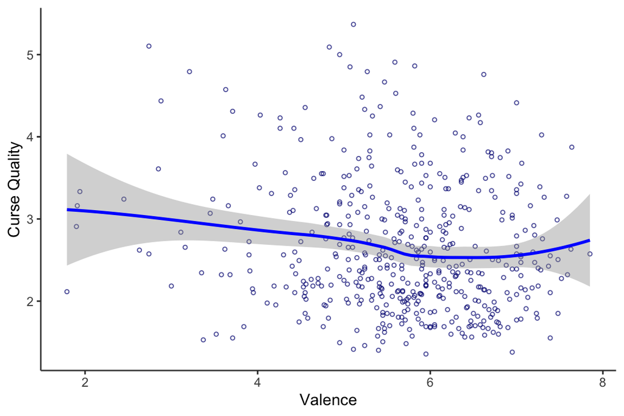

```r
# scatterplot with valence on X axis and curse quality on Y axis
ggplot(curse, aes(curse$valence, curse$curse_quality)) + geom_point(shape = 1, size = 1,
    color = "Navy", alpha = 0.7) + stat_smooth(method = loess, color = "blue") +
    xlab("Valence") + ylab("Curse Quality") + maura.theme
```

```r
# still need to look at whether relationship is linear, quadratic, or cubic
explore.rship <- lm(curse$valence ~ poly(curse$curse_quality, 3, raw = T), data = curse)
summary(explore.rship)  #none of the models are significant, cubic is closest to significant with t= -1.242, p = 0.215
```

```
##
## Call:
## lm(formula = curse$valence ~ poly(curse$curse_quality, 3, raw = T),
##     data = curse)
##
## Residuals:
##     Min      1Q  Median      3Q     Max
## -3.9475 -0.5615  0.0822  0.7199  2.1802
##
## Coefficients:
##                                        Estimate Std. Error t value   Pr(>|t|)
## (Intercept)                             7.66248    1.58021   4.849 0.00000168
## poly(curse$curse_quality, 3, raw = T)1 -1.93226    1.66229  -1.162      0.246
## poly(curse$curse_quality, 3, raw = T)2  0.63688    0.55362   1.150      0.251
## poly(curse$curse_quality, 3, raw = T)3 -0.07263    0.05847  -1.242      0.215
##
## Residual standard error: 1.042 on 477 degrees of freedom
## Multiple R-squared:  0.02662,    Adjusted R-squared:  0.0205
## F-statistic: 4.348 on 3 and 477 DF,  p-value: 0.004899
```